# DATA LEAKAGE ISSUE in ML

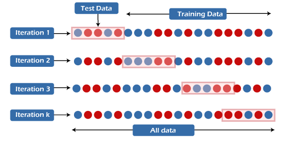

### Checking for common features: It is important to check for common features between the training data and the test data. If there are common features, it is possible that the model is learning to make predictions based on these features, which could lead to data leakage.

### Using a time-based split: If the data is time-series data, it is important to use a time-based split when splitting the data into training and test sets. This will ensure that the model is not being trained on data that is from the future.

### By following these tips, we can help to avoid data leakage and build more accurate and generalizable machine learning models.

### Data leakage can significantly impact the performance and reliability of machine learning models. It occurs when information from the validation or test data inadvertently leaks into the training process, leading to overly optimistic results during model evaluation. To avoid data leakage, consider the following approaches:

### 1. Splitting Data Properly: Ensure that you split your dataset correctly into separate sets for training, validation, and testing. Data should be partitioned before any preprocessing or feature engineering steps take place.

### 2. Feature Engineering: Be cautious when creating new features based on information that would not be available at prediction time or is derived from the target variable itself. Any transformation or calculation applied to features should only use information available up until that point in time.

### 3. Time-based Splits: When working with time series data, it's important to respect temporal order by splitting your data chronologically instead of randomly shuffling it. This ensures that future events are not used to predict past events.

### 4. Cross-Validation Techniques: Use appropriate cross-validation techniques such as k-fold cross-validation or stratified sampling while evaluating models during hyperparameter tuning and model selection processes.

### 5. Preprocessing Steps: Make sure any preprocessing steps (e.g., scaling, imputation) are performed separately on each fold during cross-validation rather than applying them globally to the entire dataset beforehand.

### 6.External Information : Avoid using external information (e.g., future values, additional datasets) for building your model if they wouldn't be accessible at prediction time.

### 7.Domain Knowledge & Common Sense : Carefully analyze your problem domain and have a good understanding of what constitutes potential sources of leakage in terms of variables/features used.

### 8.Data Pipeline Design : Designing a proper pipeline where transformations/operations occur within respective folds/splits can help prevent leakage

### 9.Regularization Techniques : Incorporating regularization techniques like L1/L2 regularization (to penalize complex models), dropout layers in neural networks etc can help mitigate overfitting and reduce the impact of leakage.

### 10. Continuous Monitoring : Continuously monitor your model's performance on unseen data, and be vigilant for any signs of unexpected accuracy or unrealistic results that could indicate data leakage.

### By following these best practices, you can minimize the risk of data leakage and build robust machine learning models with accurate evaluation metrics.

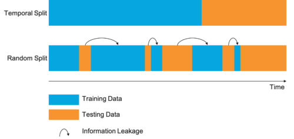

### Data leakage is a problem in machine learning that occurs when the model is trained on data that contains information about the target variable that will not be available at test time. This can lead to the model overfitting the training data and performing poorly on new data.

### There are several effects of data leakage on model building. First, it can lead to the model being overly optimistic about its performance. This is because the model is essentially being trained on data that it knows the answers to. As a result, it may appear to be very accurate on the training data, but this accuracy will not be reflected in its performance on new data.

### Second, data leakage can lead to the model being biased. This is because the model is being trained on data that is not representative of the real world. As a result, the model may learn to make predictions that are not accurate or generalizable to new data.

### Third, data leakage can make it difficult to evaluate the model's performance. This is because the model may be overfitting the training data, which will make it appear more accurate than it actually is. As a result, it may be difficult to determine whether the model is actually performing well or not.

# WAYS TO AVOID DATA LEAKAGE

### By avoiding data leakage, we can build more accurate and generalizable machine learning models.

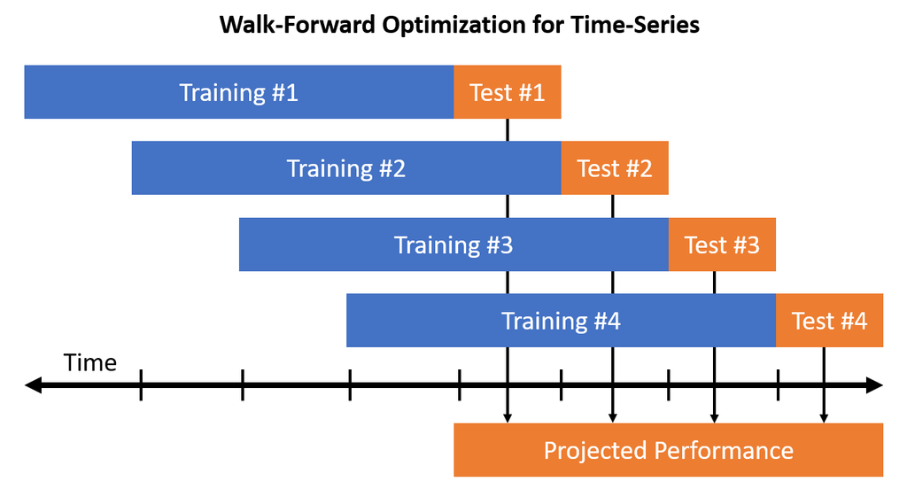